# Biometry-03

John Reddy Peasari

# Setting directory

```r
dir <- getwd()
setwd(dir)
```

# Problem 1

## Loading the data

```r
data = read.csv("h5p1.csv")
data$DENSITY <- factor(data$DENSITY,levels = c(8,15,30,45),labels = c("8","15","30","45"))
#summary(data)
str(data)
```

```
## 'data.frame':    144 obs. of  3 variables:
##  $ DENSITY: Factor w/ 4 levels "8","15","30",..: 1 1 1 1 1 1 1 1 1 1 ...
##  $ SEASON : Factor w/ 2 levels "spring","summer": 1 1 1 1 1 1 1 1 1 2 ...
##  $ EGGS   : num  2.88 2.62 1.75 3.16 2.89 ...
```

```r
levels(data$SEASON)
```

```
## [1] "spring" "summer"
```

```r
levels(data$DENSITY)
```

```
## [1] "8"  "15" "30" "45"
```

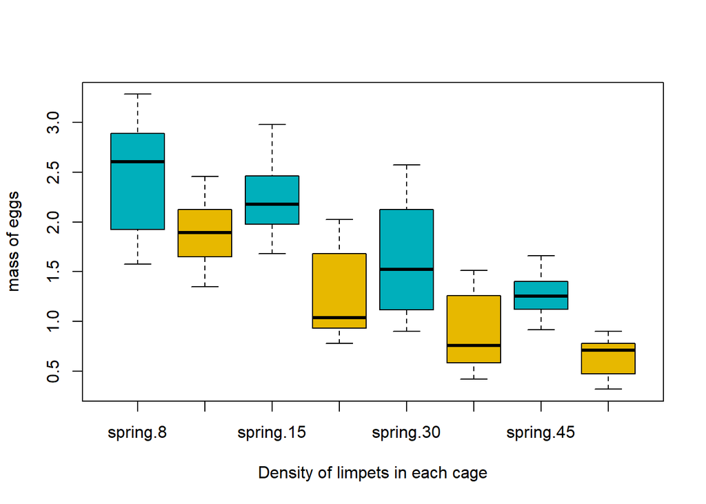

```r
# Box plot with two factor variables
boxplot(data$EGGS ~ data$SEASON * data$DENSITY, data=data, frame = T, col = c("#00AFBB", "#E7B800"), ylab="mass of eggs",xlab = "Density of limpets in each cage")
```

## Assumptions of the problem

# H01: There is no difference in the means of factor DENSITY

# H01: There is no difference in the means of factor SEASON

# H01: There is no interaction between factors DENSITY and SEASON

# Ha1: There is a difference in the means of factor DENSITY

# Ha1: There is a difference in the means of factor SEASON

# Ha1: There is an interaction between factors DENSITY and SEASON

Two-way ANOVA test is used to evaluate simultaneously the effect of two or more grouping variables (A and B) on a response variable.The grouping variables are also known as factors. The different categories (groups) of a factor are called levels. The number of levels can vary between factors. The level combinations of factors are called cell.Here, factors are DENSITY and SEASON and response variable is EGGS. Each factor has levels. Density has 4 levels and SEASON has two levels. When the sample sizes within cells are equal, we have the so-called balanced design. In this case the standard two-way ANOVA test can be applied. As the data contains two fixed factors, each with multiple levels, a Model I two-way ANOVA seems to be the most appropriate test to conduct.

```r
# With Interaction effect
# Performing ANOVA
h5p1.2way.aov_model2 = aov(data$EGGS~data$DENSITY*data$SEASON)
summary(h5p1.2way.aov_model2)
```

```
##                           Df Sum Sq Mean Sq F value Pr(>F)
## data$DENSITY               3  31.70  10.568   69.94 <2e-16 ***
## data$SEASON                1  19.50  19.501  129.06 <2e-16 ***
## data$DENSITY:data$SEASON   3   0.99   0.329    2.18 0.0933 .
## Residuals                136  20.55   0.151
## ---
## Signif. codes:  0 '***' 0.001 '**' 0.01 '*' 0.05 '.' 0.1 ' ' 1
```

# Checking the assumptions

## Normality

### Ho: Normal data

### Ha: Not normal data

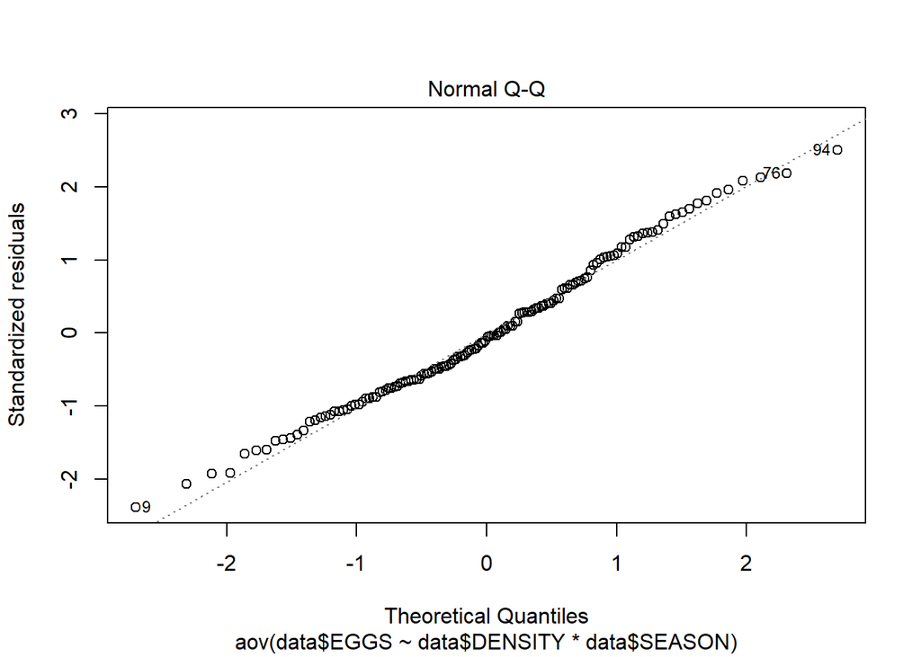

```r
res = h5p1.2way.aov_model2$residuals ### Extracting residuals

plot(h5p1.2way.aov_model2, 2)
```

```r
shapiro.test(h5p1.2way.aov_model2$residuals)
```

```
##
##  Shapiro-Wilk normality test
##
## data:  h5p1.2way.aov_model2$residuals
## W = 0.98803, p-value = 0.2514
```

Q-Q plot clearly revels that, almost all the data points are lying on the diagonal line indicating the data normality. The Shapiro test gives p values of 0.2514, suggesting that the distribution of the data are not significantly different from the normal distribution. We assume normality.

# Homogeneity of Variance

## Ho: Equal variences

## Ha: Unequal variences

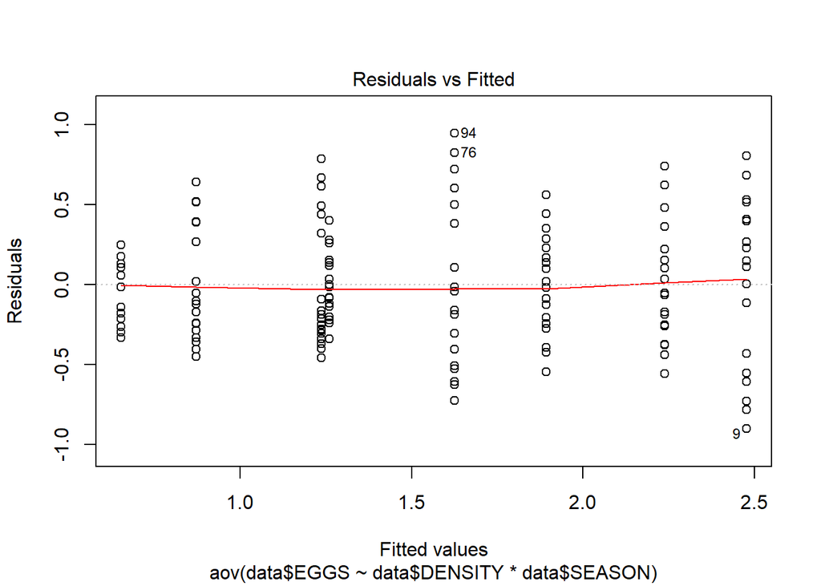

```r
plot(h5p1.2way.aov_model2, 1)
```

```r
library(car)
leveneTest(EGGS~DENSITY*SEASON, data = data)
```

```
## Levene's Test for Homogeneity of Variance (center = median)
##        Df F value    Pr(>F)
## group   7  3.8446 0.0007595 ***
##       136
## ---
## Signif. codes:  0 '***' 0.001 '**' 0.01 '*' 0.05 '.' 0.1 ' ' 1
```

Levenes test revaled that, the variecnes are not equal. The p value is less than the threshold. Hence, we fail to accept the NULL hypothesis, which suggests non-equal variences.